# Final Penguins

Ryan Spake

12/12/2021

## R Markdown

Dataset aquired from kaggle. Data is from biologists collecting data on penguins:

https://www.kaggle.com/parulpandey/palmer-archipelago-antarctica-penguin-data?select=penguins_lter.csv

## Prepare the data

Here we are omitting all missing data, Creating dummy variables for island and species, then converting sex into binary.

```r
library(caret)
library(class)
library(dplyr)
library(gmodels)
library(knitr)
library(rmarkdown)
library(tidyverse)
library(dplyr)
library(factoextra)
```

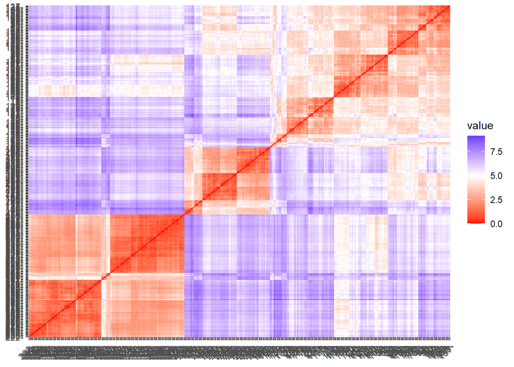

```r
DF_Penguins <- read.csv("C:\\Users\\rspake1\\Desktop\\penguins_lter.csv")
DF_Penguins <- na.omit(DF_Penguins)
Island <- dummyVars(~Island,DF_Penguins)
IslDV <- predict(Island, DF_Penguins)

Species <- dummyVars(~Species,DF_Penguins)
SpecDV <- predict(Species, DF_Penguins)


DF_Penguins <- subset(DF_Penguins, select = -c(Island))
DF_Penguins$Clutch.Completion <- ifelse(DF_Penguins$Clutch.Completion == "Yes",1,0)
DF_Penguins$Sex <- ifelse(DF_Penguins$Sex == "MALE",1,0)

dvDF_Penguins <- cbind(DF_Penguins,IslDV,SpecDV)


clust_constraint <- dvDF_Penguins %>% select_if(is.numeric)
clust_constraint$Sample.Number = NULL



set.seed(2)

clust_constraint <- scale(clust_constraint)
distance <- get_dist(clust_constraint)
fviz_dist(distance)
```

## Finding ideal K

Given that we are seperationg by, islands, k=3 is obvious, though the code below confirms this.

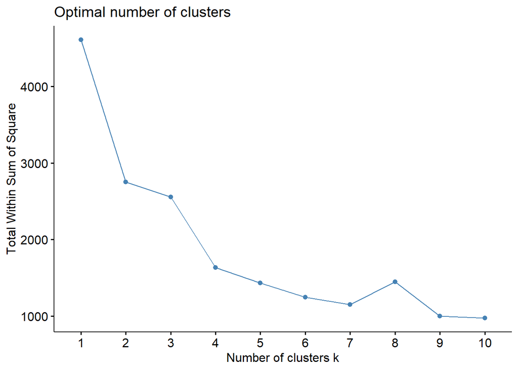

```r
clust_constraint <- scale(clust_constraint)
fviz_nbclust(clust_constraint,kmeans, method = "wss")
```

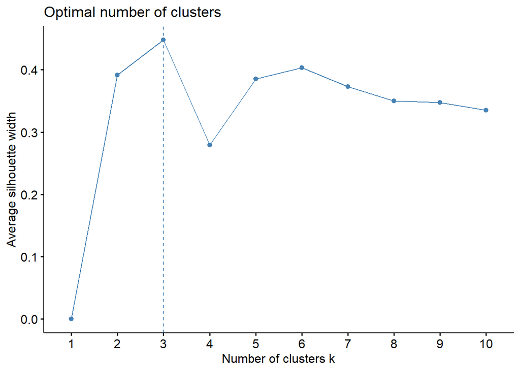

```r
fviz_nbclust(clust_constraint,kmeans, method = "silhouette")
```

## Visualize clustering -Kmeans

Below we are visually representing the different groups and how they differ statistically.

```r
k2 <- kmeans(clust_constraint, centers = 3, nstart = 25)

k2$centers
```

```
##   Clutch.Completion Culmen.Length..mm. Culmen.Depth..mm. Flipper.Length..mm.
## 1        0.14994823          0.6350952        -1.0744525            1.134141
## 2        0.03557682         -0.9630941         0.6177020           -0.789354
## 3       -0.34791067          0.8703681         0.6565258           -0.403974
##   Body.Mass..g.          Sex Delta.15.N..o.oo. Delta.13.C..o.oo. IslandBiscoe
## 1     1.0665813  0.007839384        -0.8845046        -0.6257757    0.9924505
## 2    -0.6360437 -0.011204851         0.2289921        -0.1422800   -0.3813750
## 3    -0.6035934  0.009305659         1.1286817         1.4388972   -1.0045536
##   IslandDream IslandTorgersen SpeciesAdelie Penguin (Pygoscelis adeliae)
## 1 -0.74984799      -0.3967572                                 -0.8624216
## 2  0.01702676       0.5318235                                  1.1560120
## 3  1.32956240      -0.3967572                                 -0.8624216
##   SpeciesChinstrap penguin (Pygoscelis antarctica)
## 1                                       -0.5039652
## 2                                       -0.5039652
## 3                                        1.9782513
##   SpeciesGentoo penguin (Pygoscelis papua)
## 1                                1.3037452
## 2                               -0.7646967
## 3                               -0.7646967
```

```r
k2$size
```

```
## [1] 122 141  67
```

```r
k2$cluster[11]
```

```
## 18
##  2
```

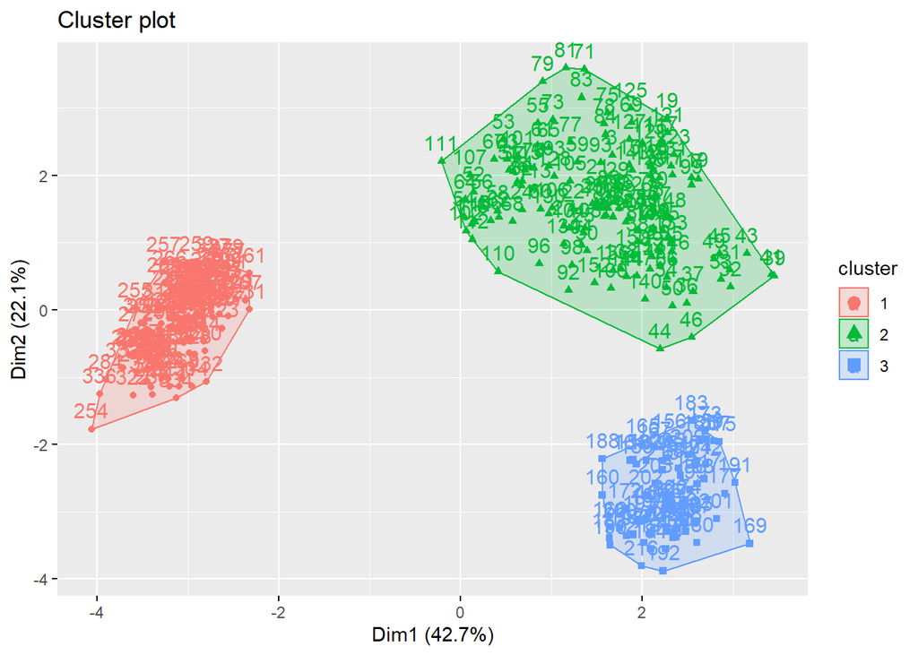

```r
fviz_cluster(k2, data = clust_constraint)
```

## Identifiy details of clusters

Prepare again

Below we are reestablishing the clusters using clustering.

```r
library(gmodels)
library(knitr)
library(rmarkdown)
library(readr)
library(tidyverse)
library(caret)
library(cluster)
library(factoextra)
library(RColorBrewer)
```

```r
library(dplyr)
library(ggraph)
library(igraph)
DF_Penguins <- read.csv("C:\\Users\\rspake1\\Desktop\\penguins_lter.csv")
DF_Penguins <- na.omit(DF_Penguins)

Island <- dummyVars(~Island,DF_Penguins)
IslDV <- predict(Island, DF_Penguins)

Species <- dummyVars(~Species,DF_Penguins)
SpecDV <- predict(Species, DF_Penguins)



DF_Penguins$Clutch.Completion <- ifelse(DF_Penguins$Clutch.Completion == "Yes",1,0)
DF_Penguins$Sex <- ifelse(DF_Penguins$Sex == "MALE",1,0)

dvDF_Penguins <- cbind(DF_Penguins,IslDV,SpecDV)




numeric_Penguins <- dvDF_Penguins %>% select_if(is.numeric)
numeric_Penguins$Sample.Number = NULL


DF_Penguins_norm <- as.data.frame(scale(numeric_Penguins))

d <- dist(DF_Penguins_norm, method = "euclidean")
```

## Select Method

Now we test for which method of clustering will work the best.

[output not shown]

## Agnes visualization

Now we develop and Agnes Dendogram to visualize how the clusters separate.

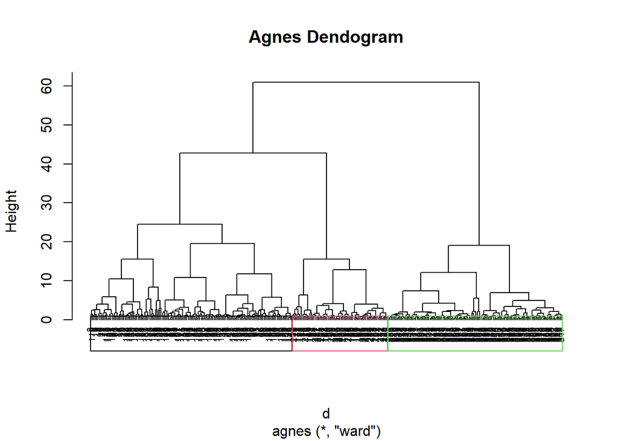

```r
hc <- agnes(d, method = "ward")
pltree(hc, cex = 0.6, hang = -1, main = "Agnes Dendogram")
rect.hclust(hc, k = 3, border = 1:5)
```

## Develop cluster partitions

In the two sections below we are creating the cluster partitions, then developing the centroids for each group.

```r
cluster_part <- cutree(hc, k = 3)
Penguins_clustered <- mutate(DF_Penguins_norm, cluster = cluster_part)
set.seed(23)

part_index <- createDataPartition(Penguins_clustered$cluster, p = 0.7, list = FALSE)
Part_A <- Penguins_clustered[part_index,]
Part_B <- Penguins_clustered[-part_index,]
```

```r
Part_A_centroid <- Part_A %>% gather("features", "values", -cluster) %>% group_by(cluster,features) %>% summarise(mean_values = mean(values)) %>% spread(features, mean_values)
cluster_B <- data.frame(data = seq(1,nrow(Part_B), 1), Cluster_B_Part = rep(0,nrow(Part_B)))

for (x in 1:nrow(Part_B)) {
  cluster_B$Cluster_B_Part[x] <- which.min(as.matrix(get_dist(as.data.frame(rbind(Part_A_centroid[-1], Part_B[x, -length(Part_B)]))))[4,-4])
}

cluster_B <- cluster_B %>% mutate(original_clusters = Part_B$cluster)
mean(cluster_B$Cluster_B_Part) == cluster_B$original_clusters
```

```
##  [1] FALSE FALSE FALSE FALSE FALSE FALSE FALSE FALSE FALSE FALSE FALSE FALSE
## [13] FALSE FALSE FALSE FALSE FALSE FALSE FALSE FALSE FALSE FALSE FALSE FALSE
## [25] FALSE FALSE FALSE FALSE FALSE FALSE FALSE FALSE FALSE FALSE FALSE FALSE
## [37] FALSE FALSE FALSE FALSE FALSE FALSE FALSE FALSE FALSE FALSE FALSE FALSE
## [49] FALSE FALSE FALSE FALSE FALSE FALSE FALSE FALSE FALSE FALSE FALSE FALSE
## [61] FALSE FALSE FALSE FALSE FALSE FALSE FALSE FALSE FALSE FALSE FALSE FALSE
## [73] FALSE FALSE FALSE FALSE FALSE FALSE FALSE FALSE FALSE FALSE FALSE FALSE
## [85] FALSE FALSE FALSE FALSE FALSE FALSE FALSE FALSE FALSE FALSE FALSE FALSE
## [97] FALSE FALSE
```

```r
split_clusters <- split(Penguins_clustered, Penguins_clustered$cluster)
mean_split <- lapply(split_clusters,colMeans)
mean_split
```

```
## $`1`
##                                Clutch.Completion
##                                       0.03557682
##                               Culmen.Length..mm.
##                                      -0.96309414
##                                Culmen.Depth..mm.
##                                       0.61770198
##                              Flipper.Length..mm.
##                                      -0.78935398
##                                    Body.Mass..g.
##                                      -0.63604369
##                                              Sex
##                                      -0.01120485
##                                Delta.15.N..o.oo.
##                                       0.22899214
##                                Delta.13.C..o.oo.
##                                      -0.14228000
##                                     IslandBiscoe
##                                      -0.38137499
##                                      IslandDream
##                                       0.01702676
##                                  IslandTorgersen
##                                       0.53182347
##       SpeciesAdelie Penguin (Pygoscelis adeliae)
##                                       1.15601195
## SpeciesChinstrap penguin (Pygoscelis antarctica)
##                                      -0.50396515
##         SpeciesGentoo penguin (Pygoscelis papua)
##                                      -0.76469672
##                                          cluster
##                                       1.00000000
##
## $`2`
##                                Clutch.Completion
##                                     -0.347910674
##                               Culmen.Length..mm.
##                                      0.870368083
##                                Culmen.Depth..mm.
##                                      0.656525791
##                              Flipper.Length..mm.
```

[output cut: 40 more lines]

```
##                                     -0.625775672
##                                     IslandBiscoe
##                                      0.992450510
##                                      IslandDream
##                                     -0.749847991
##                                  IslandTorgersen
##                                     -0.396757190
##       SpeciesAdelie Penguin (Pygoscelis adeliae)
##                                     -0.862421616
## SpeciesChinstrap penguin (Pygoscelis antarctica)
##                                     -0.503965151
##         SpeciesGentoo penguin (Pygoscelis papua)
##                                      1.303745226
##                                          cluster
##                                      3.000000000
```

```r
(centroids <- do.call(rbind, mean_split))
```

```
##   Clutch.Completion Culmen.Length..mm. Culmen.Depth..mm. Flipper.Length..mm.
## 1        0.03557682         -0.9630941         0.6177020           -0.789354
## 2       -0.34791067          0.8703681         0.6565258           -0.403974
## 3        0.14994823          0.6350952        -1.0744525            1.134141
##   Body.Mass..g.          Sex Delta.15.N..o.oo. Delta.13.C..o.oo. IslandBiscoe
## 1    -0.6360437 -0.011204851         0.2289921        -0.1422800   -0.3813750
## 2    -0.6035934  0.009305659         1.1286817         1.4388972   -1.0045536
## 3     1.0665813  0.007839384        -0.8845046        -0.6257757    0.9924505
##   IslandDream IslandTorgersen SpeciesAdelie Penguin (Pygoscelis adeliae)
## 1  0.01702676       0.5318235                                  1.1560120
## 2  1.32956240      -0.3967572                                 -0.8624216
## 3 -0.74984799      -0.3967572                                 -0.8624216
##   SpeciesChinstrap penguin (Pygoscelis antarctica)
## 1                                       -0.5039652
## 2                                        1.9782513
## 3                                       -0.5039652
##   SpeciesGentoo penguin (Pygoscelis papua) cluster
## 1                               -0.7646967       1
## 2                               -0.7646967       2
## 3                                1.3037452       3
```

## Cluster details

Finally, We are graphing the clusters to identify the details of each cluster.

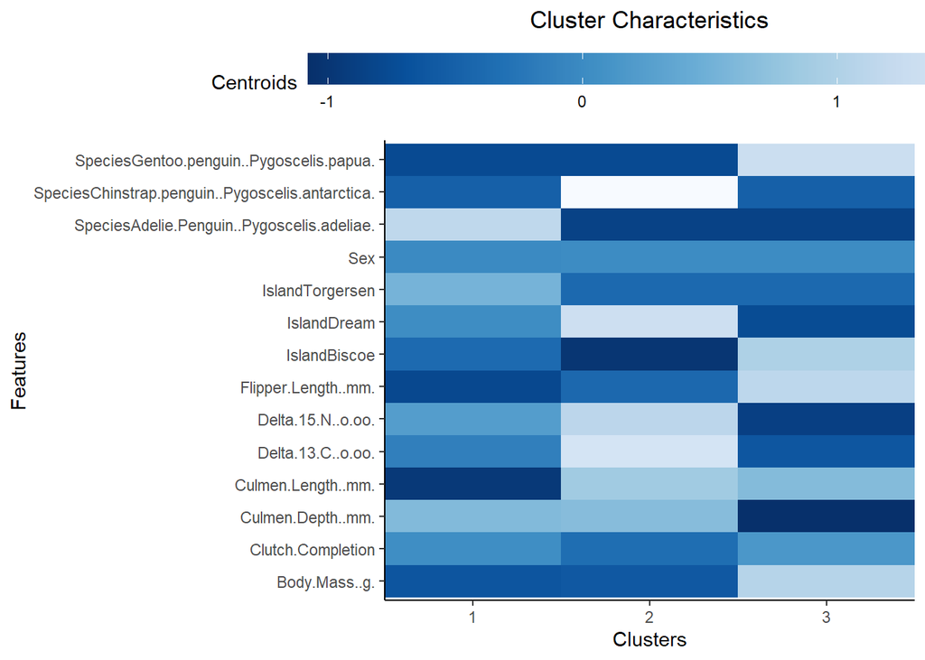

```r
hc.graph <-
  colorRampPalette(rev(brewer.pal(9, 'Blues')), space = 'Lab')
data.frame(centroids) %>% gather("features", "values",-cluster) %>%
  ggplot(aes(
    x = factor(cluster),
    y = features,
    fill = values
  )) +
  geom_tile() + theme_classic() +
  theme(
    legend.position = "top",
    plot.title = element_text(hjust = 0.5),
    legend.key.width = unit(3, "cm"),
  ) +
  scale_x_discrete(expand = c(0, 0)) +
  scale_fill_gradientn(colours = hc.graph(100)) +
  labs(title = "Cluster Characteristics",
       x = "Clusters",
       y = "Features",
       fill = "Centroids")
```

## Checking individuals

Below We evaluate k2 so we can Identify which individual Penguin goes in Which cluster.

```r
k2
```

```
## K-means clustering with 3 clusters of sizes 122, 141, 67
##
## Cluster means:
##   Clutch.Completion Culmen.Length..mm. Culmen.Depth..mm. Flipper.Length..mm.
## 1        0.14994823          0.6350952        -1.0744525            1.134141
## 2        0.03557682         -0.9630941         0.6177020           -0.789354
## 3       -0.34791067          0.8703681         0.6565258           -0.403974
##   Body.Mass..g.          Sex Delta.15.N..o.oo. Delta.13.C..o.oo. IslandBiscoe
## 1     1.0665813  0.007839384        -0.8845046        -0.6257757    0.9924505
## 2    -0.6360437 -0.011204851         0.2289921        -0.1422800   -0.3813750
## 3    -0.6035934  0.009305659         1.1286817         1.4388972   -1.0045536
##   IslandDream IslandTorgersen SpeciesAdelie Penguin (Pygoscelis adeliae)
## 1 -0.74984799      -0.3967572                                 -0.8624216
## 2  0.01702676       0.5318235                                  1.1560120
## 3  1.32956240      -0.3967572                                 -0.8624216
```

[output cut: 53 more lines]